# Experiment7_AllCode

Brianne Palmer

2023-01-23

This is the R code for all the analyses performed for Experiment 7 (water lilies, top and bottom). If there are questions about the code please contact Brianne Palmer (bpalmer[at]uni-bonn.de)

There are several packages required to perform these analyses and create the figures. There are probably easier ways to do some of this, but if the code works, why change it?

Data will be upoaded to scibo with the same file names

```r
counts_wtax <- fread("/Users/briannepalmer/Library/CloudStorage/OneDrive-Personal/LeafFossilization/Dataframes_to_merge/merged_edited.csv") # the csv file contains the merged 16S, 18S, and ITS sequences, it was edited to change the names of taxa so the naming matched across the three databases

# the metadata
SampleID <- c("NuBotR1", "NuBotR2", "NuBotR3", "NuTopR1", "NuTopR2", "NuTopR3", "NyBotR1", "NyBotR2", "NyBotR3", "NyTopR1", "NyTopR2", "NyTopR3")
Location <-c("buried", "buried", "buried", "floating", "floating", "floating", "buried", "buried", "buried", "floating", "floating", "floating")
plant <- c("Nuphar", "Nuphar", "Nuphar", "Nuphar", "Nuphar", "Nuphar", "Nymphaea", "Nymphaea", "Nymphaea", "Nymphaea", "Nymphaea", "Nymphaea")
treatment <- c("NuBot", "NuBot", "NuBot", "NuTop", "NuTop", "NuTop", "NyBot", "NyBot", "NyBot", "NyTop", "NyTop", "NyTop")

metadata <- data.frame(SampleID, Location, plant, treatment)
```

The counts_wtax file needs to be updated to include the relative abundance and name the ASVs

```r
# make new columns with count and relative abundance
counts_wtax[,c(2:13)] <-sweep(counts_wtax[,c(2:13)], 2, colSums(counts_wtax[,c(2:13)]), `/`)
counts_wtax$n <- rowSums(counts_wtax[ , c(2:13)], na.rm=TRUE)
x <- seq(1:8786)
otu.names <- as.vector(paste0("ASV", x))
counts_wtax$otu <- otu.names
```

Make a taxa and otu files for future use

```r
tax.only <- counts_wtax[,c(1, 14:20)]
count.only <- counts_wtax[,c(2:13)]

otu.table <- counts_wtax[,c(23, 2:13)]
otu.table <- otu.table[,-1]
otu.table <- as.matrix(otu.table)
rownames(otu.table) <- counts_wtax$otu

tax.table <- counts_wtax[,c(23,14:20)]
tax.table <- as.matrix(tax.table)
rownames(tax.table) <- counts_wtax$otu
tax.table <- tax.table[,-1]

# store these files in a folder you will remember
fwrite(otu.table, file = "/Users/briannepalmer/Library/CloudStorage/OneDrive-Personal/LeafFossilization/waterliliesOTU.csv")
```

```
## x being coerced from class: matrix to data.table
```

```r
fwrite(tax.table, file = "/Users/briannepalmer/Library/CloudStorage/OneDrive-Personal/LeafFossilization/waterliliesTAX.csv")
```

```
## x being coerced from class: matrix to data.table
```

```r
# make relative abundance df
count.only <-sweep(count.only, 2, colSums(count.only), `/`)
count.only[c(1:12)] <- sapply(count.only[c(1:12)], as.numeric)
```

Make another table with the ASVs as columns, this is necessary for the PCOA

```r
transformed <- t(count.only)
colnames(transformed) <- tax.only$Feature.ID
transformed[is.na(transformed)] <-0
transformed[c(1:8786)] <- sapply(transformed[c(1:8786)],as.numeric)
transformed <- as.matrix(transformed)
transformed <- matrix(
  as.numeric(transformed), ncol = 8786)
```

And make similar tables for each kingdom

```r
# prokaryote only
prokaryote <- counts_wtax %>% filter(kingdom == "Bacteria")
transformed.p <- t(prokaryote[,c(2:13)])
colnames(transformed.p) <- prokaryote$Feature.ID
transformed.p[is.na(transformed.p)] <-0
transformed.p <- as.matrix(transformed.p)

# eukaryote only
eukaryote <- counts_wtax %>% filter(kingdom == "Eukaryota")
transformed.e <- t(eukaryote[,c(2:13)])
colnames(transformed.e) <- eukaryote$Feature.ID
transformed.e[is.na(transformed.e)] <-0
transformed.e <- as.matrix(transformed.e)

# archaea only
archaea <- counts_wtax %>% filter(kingdom == "Archaea")
transformed.a <- t(archaea[,c(2:13)])
colnames(transformed.a) <- archaea$Feature.ID
transformed.a[is.na(transformed.a)] <-0
transformed.a <- as.matrix(transformed.a)
```

Time to do the PCOA – for each kingdom

First, make a bray curtis matrix

```r
otu.bray.p <- vegdist(transformed.p, method = "bray")
otu.bray.e <- vegdist(transformed.e, method = "bray")

pcoaVS.p <- ecodist::pco(otu.bray.p, negvals = "zero", dround = 0)
pcoaVS.e <- ecodist::pco(otu.bray.e, negvals = "zero", dround = 0)
```

Make dataframe for plot with vectors and metadata

```r
pcoa1.p = pcoaVS.p$vectors[,1] # adds the points of the NMDS 1 dimmension
pcoa2.p = pcoaVS.p$vectors[,2] # adds the points of the NMDS 2 dimmension
pcoa1.e = pcoaVS.e$vectors[,1] # adds the points of the NMDS 1 dimmension
pcoa2.e = pcoaVS.e$vectors[,2] # adds the points of the NMDS 2 dimmension

MDS = data.frame(pcoa1.p = pcoa1.p, pcoa2.p = pcoa2.p, pcoa1.e = pcoa1.e, pcoa2.e = pcoa2.e)
MDS = cbind(MDS, metadata)
```

STATISTICS TIME! (PERMANOVA)

```r
set.seed(12345)
adonis2(transformed ~ Location, metadata)
```

```
## Permutation test for adonis under reduced model
## Terms added sequentially (first to last)
## Permutation: free
## Number of permutations: 999
##
## adonis2(formula = transformed ~ Location, data = metadata)
##          Df SumOfSqs    R2      F Pr(>F)
## Location  1  0.47727 0.187 2.3002  0.024 *
## Residual 10  2.07493 0.813
## Total    11  2.55220 1.000
## ---
## Signif. codes:  0 '***' 0.001 '**' 0.01 '*' 0.05 '.' 0.1 ' ' 1
```

```r
adonis2(transformed ~ plant, metadata)# 0.019
```

```
## Permutation test for adonis under reduced model
## Terms added sequentially (first to last)
## Permutation: free
## Number of permutations: 999
##
## adonis2(formula = transformed ~ plant, data = metadata)
##          Df SumOfSqs      R2      F Pr(>F)
## plant     1  0.18144 0.07109 0.7653  0.608
## Residual 10  2.37076 0.92891
## Total    11  2.55220 1.00000
```

```r
adonis2(transformed.p ~ Location, metadata) # 0.019
```

```
## Permutation test for adonis under reduced model
## Terms added sequentially (first to last)
## Permutation: free
## Number of permutations: 999
##
## adonis2(formula = transformed.p ~ Location, data = metadata)
##          Df SumOfSqs     R2      F Pr(>F)
## Location  1  0.49982 0.1952 2.4254  0.028 *
## Residual 10  2.06077 0.8048
## Total    11  2.56059 1.0000
## ---
## Signif. codes:  0 '***' 0.001 '**' 0.01 '*' 0.05 '.' 0.1 ' ' 1
```

```r
adonis2(transformed.e ~ Location, metadata) # 0.086
```

```
## Permutation test for adonis under reduced model
## Terms added sequentially (first to last)
## Permutation: free
## Number of permutations: 999
##
## adonis2(formula = transformed.e ~ Location, data = metadata)
##          Df SumOfSqs      R2      F Pr(>F)
## Location  1  0.32986 0.14553 1.7032  0.064 .
## Residual 10  1.93671 0.85447
## Total    11  2.26657 1.00000
## ---
## Signif. codes:  0 '***' 0.001 '**' 0.01 '*' 0.05 '.' 0.1 ' ' 1
```

Time to make some plots, but first, I want to make a color scheme for all the future figures. Hopefully, it is color blind friendly

```r
pal <- palette(c('#882255','#88CCEE', '#EE8866', '#44AA99', '#117733', '#332288', '#DDCC77', '#999933','#CC6677',  '#AA4499', '#DDDDDD')) # for small number of variables
largepal <- colorRampPalette(pal)(45) # for large number of variables
two.pal <- palette(c('#882255','#88CCEE'))
```

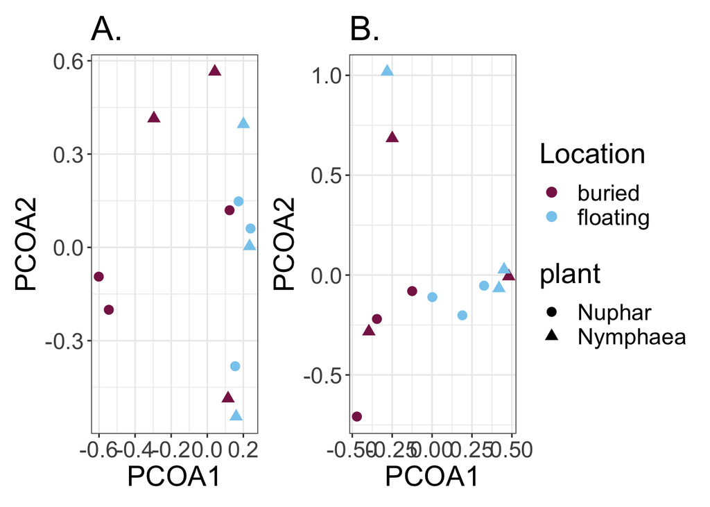

Look at the abundance of each phylum and make bar charts for the phyla within each kingdom

For this, we have to make another table, I am calling it pivot here but it is a transposed table essentially

```r
# remove ASVs that have no information
pivot <- counts_wtax %>% filter(kingdom != "Unassigned", kingdom != "Alveolata") %>% pivot_longer(cols = c(NuBotR1:NyTopR3), names_to = "SampleID")

# if there are blanks, these should be NA
pivot[pivot == ""] <- NA

pivot <- pivot %>% group_by(SampleID, kingdom, phylum, class, order, family, genus, species, otu) %>% dplyr::summarize(value = sum(value))
```

[output not shown]

```r
phylum <- pivot %>% dplyr::select(SampleID, kingdom, phylum, value) %>% group_by(SampleID, kingdom, phylum) %>% summarize(value = sum(value))
```

```
## `species`
```

```r
phylum <- phylum %>% pivot_wider(names_from = phylum, values_from = value)

phylum[c(3:64)] <- sapply(phylum[c(3:64)],as.numeric)
phylum[is.na(phylum)] <- 0
```

```r
phylum <- merge(metadata, phylum, by = "SampleID")

# make a longer table, this is easier to graph with (hence why I named it ggplot)
phylum.ggplot <- pivot_longer(phylum, cols = Crenarchaeota:Viridiplantae,names_to = "phylum", values_to = "value")
```

Graph prokaryotic phyla

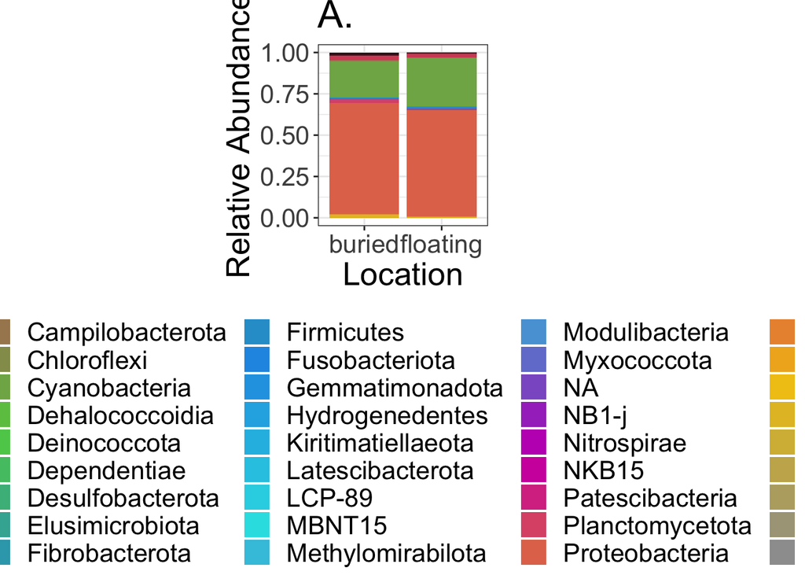

Eukaryotic Phyla

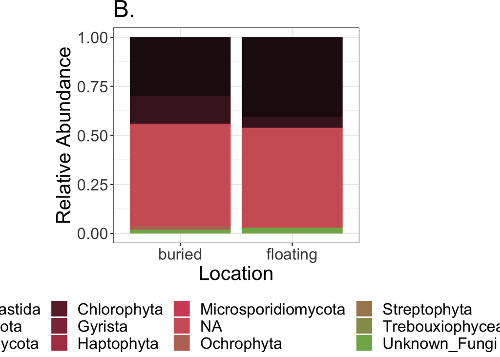

Do an ANOVA to determine if there are any phylum level differences

```r
phylum.anova <- phylum.ggplot %>% group_by(phylum) %>%
  do(broom::tidy(TukeyHSD(aov(value ~ Location, data = .)))) %>%
  ungroup

phylum.anova.sig <- phylum.anova %>% filter(adj.p.value < 0.05)

phylum.anova.sig # Crenarchaeota, Grysta, Myxococcota, and Summerlaeota vary between locations
```

```
## # A tibble: 7 × 8
##   phylum           term     contrast  null.…¹ estimate conf.low conf.h…² adj.p…³
##   <chr>            <chr>    <chr>       <dbl>    <dbl>    <dbl>    <dbl>   <dbl>
## 1 Crenarchaeota    Location floating…       0 -1.28e-5 -2.44e-5 -1.30e-6  0.0302
## 2 Desulfobacterota Location floating…       0 -9.32e-4 -1.84e-3 -2.13e-5  0.0452
## 3 Euryarchaeota    Location floating…       0 -1.26e-4 -2.44e-4 -8.62e-6  0.0362
## 4 Gyrista          Location floating…       0 -6.00e-6 -1.17e-5 -3.45e-7  0.0382
## 5 Halobacterota    Location floating…       0 -1.43e-4 -2.83e-4 -3.68e-6  0.0446
## 6 Myxococcota      Location floating…       0 -2.78e-4 -5.50e-4 -6.60e-6  0.0450
## 7 Sumerlaeota      Location floating…       0 -6.02e-6 -1.19e-5 -1.43e-7  0.0450
## # … with abbreviated variable names ¹null.value, ²conf.high, ³adj.p.value
```

It can be helpful to make the data into a phyloseq object for future analyses, but I am not very good with the phyloseq functions

```r
otu.table <- otu_table(otu.table, taxa_are_rows = TRUE)
tax.table <- tax_table(tax.table)
sam.data <- as.matrix(metadata)
sam.data <- sample_data(metadata)
rownames(sam.data) <- metadata$SampleID

ps <- phyloseq(otu.table, tax.table, sam.data)
random_tree = rtree(ntaxa(ps), rooted=TRUE, tip.label=taxa_names(ps))

ps = merge_phyloseq(ps,random_tree)
```

[output not shown]

[output not shown]

[output not shown]

[output not shown]

[output not shown]

[output not shown]

[output not shown]

[output not shown]

[output not shown]

[output not shown]

[output not shown]

[output not shown]

[output not shown]

[output not shown]

```r
ps <- subset_taxa(ps, kingdom !="Unassigned")
```

[output not shown]

[output not shown]

[output not shown]

[output not shown]

[output not shown]

[output not shown]

[output not shown]

```r
ps <- subset_taxa(ps, phylum != "NA")
```

[output not shown]

[output not shown]

[output not shown]

[output not shown]

[output not shown]

[output not shown]

[output not shown]

Next, calculate richness and diversity and make more plots

Make a new dataframe with the ASVs from the pivot dataframe

```r
ASV <- pivot %>% dplyr::select(SampleID, otu, value) # the pivot dataframe also removed all the ASVs that were unassigned at the kingdom level
```

```
## `family`, `genus`, `species`
```

```r
ASV <- ASV %>% pivot_wider(names_from = otu, values_from = value)
ASV[c(9:6831)] <- sapply(ASV[c(9:6831)],as.numeric)
ASV[c(9:6831)][is.na(ASV[c(9:6831)])] <- 0
ASV <- merge(metadata, ASV)
ASV.gp <- ASV %>% group_by(SampleID, Location, plant, treatment) %>% summarize_at(vars(ASV2507:ASV8786), sum)
```

Make vectors for richness

```r
nutop.rich <- specnumber((ASV.gp %>% filter(treatment == "NuTop"))[-c(1:4)])
nubot.rich <- specnumber((ASV.gp %>% filter(treatment == "NuBot"))[-c(1:4)])
nytop.rich <- specnumber((ASV.gp %>% filter(treatment == "NyTop"))[-c(1:4)])
nybot.rich <- specnumber((ASV.gp %>% filter(treatment == "NyBot"))[-c(1:4)])
```

Make vectors for diversity using the shannon index

```r
nutop.div <- vegan::diversity((ASV.gp %>% filter(treatment == "NuTop"))[-c(1:4)], index = "shannon")
nubot.div <- vegan::diversity((ASV.gp %>% filter(treatment == "NuBot"))[-c(1:4)], index = "shannon")
nytop.div <- vegan::diversity((ASV.gp %>% filter(treatment == "NyTop"))[-c(1:4)], index = "shannon")
nybot.div <- vegan::diversity((ASV.gp %>% filter(treatment == "NyBot"))[-c(1:4)],index = "shannon")
```

Make dataframe with diversity and richness vectors

```r
richness <- c(nubot.rich, nutop.rich, nybot.rich, nytop.rich)
diversity <- c(nubot.div, nutop.div, nybot.div, nytop.div)

rich.div <- data.frame(ASV.gp$Location, ASV.gp$plant, ASV.gp$treatment, richness, diversity)
```

STATISTICS TIME! Anovas to determine differences in richness and diversity

```r
set.seed(12345)
rich.lm <- lm(richness ~ ASV.gp.Location, data = rich.div)
rich.aov <- aov(rich.lm)
summary(rich.aov)# there is a difference in OTU richness
```

```
##                 Df  Sum Sq Mean Sq F value  Pr(>F)
## ASV.gp.Location  1 1962634 1962634   11.98 0.00611 **
## Residuals       10 1638460  163846
## ---
## Signif. codes:  0 '***' 0.001 '**' 0.01 '*' 0.05 '.' 0.1 ' ' 1
```

```r
div.lm <- lm(diversity ~ ASV.gp.Location, data = rich.div)
div.aov <- aov(div.lm)
summary(div.aov)# there is no difference in diversity
```

```
##                 Df Sum Sq Mean Sq F value Pr(>F)
## ASV.gp.Location  1  0.719  0.7186   1.144   0.31
## Residuals       10  6.283  0.6283
```

Richness plot

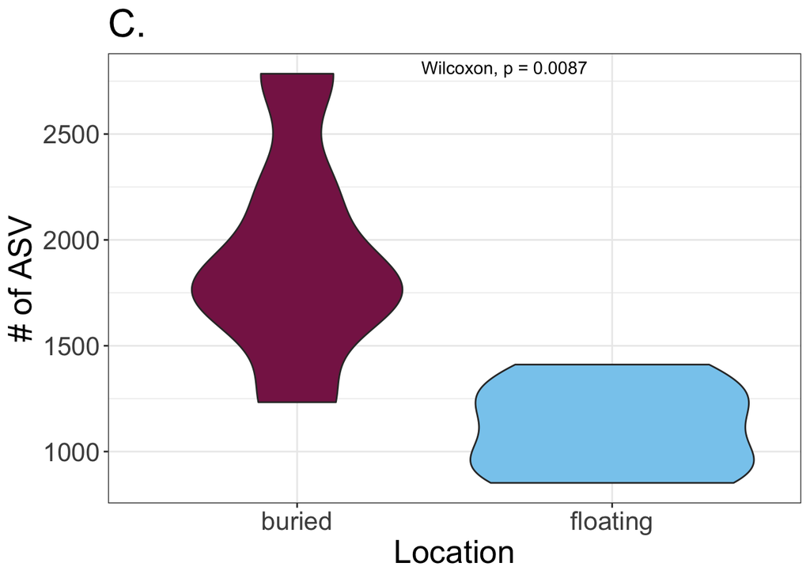

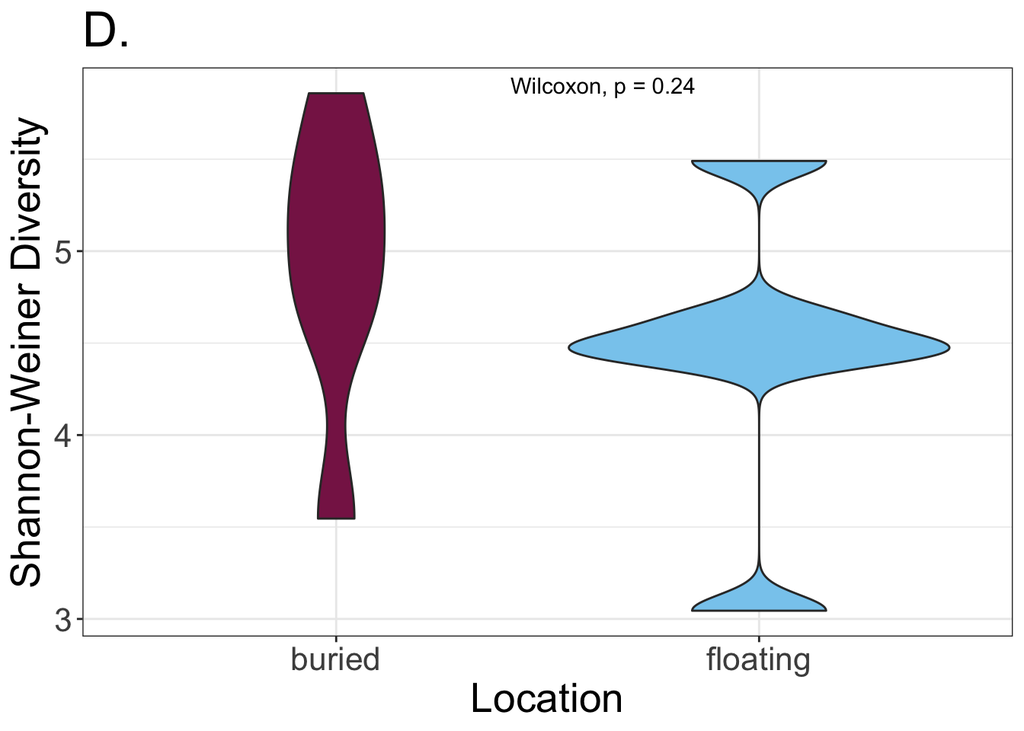

```r
ASV.b <- pivot %>% filter(kingdom == "Bacteria") %>% dplyr::select(SampleID, otu, value) # the pivot dataframe also removed all the ASVs that were unassigned at the kingdom level
```

```
## `family`, `genus`, `species`
```

```r
ASV.b <- ASV.b %>% pivot_wider(names_from = otu, values_from = value)
ASV.b[c(9:6191)] <- sapply(ASV.b[c(9:6191)],as.numeric)
ASV.b[c(9:6191)][is.na(ASV.b[c(9:6191)])] <- 0

ASV.b <- merge(metadata, ASV.b, by = "SampleID")

ASV.gp.b <- ASV.b %>% group_by(SampleID, Location, plant, treatment) %>% summarize_at(vars(ASV2:ASV6528), sum)
```

```r
nutop.rich <- specnumber((ASV.gp.b %>% filter(treatment == "NuTop"))[-c(1:11)])
nubot.rich <- specnumber((ASV.gp.b %>% filter(treatment == "NuBot"))[-c(1:11)])
nytop.rich <- specnumber((ASV.gp.b %>% filter(treatment == "NyTop"))[-c(1:11)])
nybot.rich <- specnumber((ASV.gp.b %>% filter(treatment == "NyBot"))[-c(1:11)])
```

```r
nutop.div <- vegan::diversity((ASV.gp.b %>% filter(treatment == "NuTop"))[-c(1:11)], index = "shannon")
nubot.div <- vegan::diversity((ASV.gp.b %>% filter(treatment == "NuBot"))[-c(1:11)], index = "shannon")
nytop.div <- vegan::diversity((ASV.gp.b %>% filter(treatment == "NyTop"))[-c(1:11)], index = "shannon")
nybot.div <- vegan::diversity((ASV.gp.b %>% filter(treatment == "NyBot"))[-c(1:11)],index = "shannon")
```

```r
richness.b <- c(nubot.rich, nutop.rich, nybot.rich, nytop.rich)
diversity.b <- c(nubot.div, nutop.div, nybot.div, nytop.div)

rich.div.b <- data.frame(ASV.gp.b$Location, ASV.gp.b$plant, ASV.gp.b$treatment, richness, diversity)
```